# Deterrence and Interstate Peace - A Logistic Analysis

Author

Mark Scott

Published

May 14, 2026

```r
libs <- c("tidyverse", "broom", "car", "stargazer", "pROC", "sandwich", "lmtest")
lapply(libs, library, character.only = TRUE)
rm(libs)
COWData <- read_csv("COWData.csv")
```

# 1 Introduction

## 1.1 Research Focus

This project examines deterrence theory using state-year data from the Correlates of War (COW) [^1]<sup>,</sup>[^2]<sup>,</sup>[^3]<sup>,</sup>[^4] and varieties of Democracy (V-Dem)[^5] projects. Deterrence theory posits that States with greater military capability are less likely to be attacked and therefore less likely to experience conflict participation.[^6]<sup>,</sup>[^7]<sup>,</sup>[^8] This is closely related to *Realist* theories, which argue that the distribution of relative power in the international system is the primary influence on the probability of conflict.[^9] This produces a straightforward, testable hypothesis: as military capability increases, does the probability of interstate conflict participation decrease?

The geopolitical climate of the present moment lends the question particular urgency. Both the Russian invasion of Ukraine and the United States–Iran conflict invite scrutiny of the conditions under which military capability shapes conflict outcomes. These cases also highlight distinction this project will make: deterrence theory speaks primarily to whether capable states are *attacked*, not whether they *initiate* conflict. Hard power may not deter; rather, it may enable power projection. Especially given a sufficient motivator, such as resources, a state may logically conclude that military conflict is the rational or the optimal decision. I examine both dimensions, testing whether capability reduces conflict participation in aggregate and whether its effect differs depending on whether a state enters conflict as a defender or an aggressor.

**Research Question:** Does greater military capability reduce the probability that a state participates in interstate conflict?

**Unit of Observation:** State-year

- Year ranges from 1816 to 2023.
- The number of total States per year ranges from 23 to 195.

## 1.2 Theoretical Framework

As stated above, deterrence theory holds that states with superior military capabilities impose prohibitively high costs on potential adversaries, thereby discouraging the initiation of conflict. The logic is relatively straightforward, a state that can credibly threaten retaliation deters rational actors from attacking. Under this view, the relationship between military capability and conflict victimization should be negative, or, more capable states should be attacked less frequently.

A competing possibility is that military capability enables offense as much as defense. States with significant hard power can project force, sustain extended campaigns, and bear the costs of conflict in ways that weaker states cannot. This creates a theoretical ambiguity in aggregated state-year data: capability may deter attacks while simultaneously enabling their initiation, potentially producing a null or even positive net relationship. This is why I break conflict down between defenders and aggressors.

The second theory examined here is the liberal peace thesis, which posits that democratic governance and economic interdependence jointly suppress conflict propensity.Trade ties raise the opportunity cost of war; democratic institutions create transparency and accountability that make conflict less attractive. These mechanisms may be mutually reinforcing meaning, the pacifying effect of trade could be stronger among democracies, where commercial interests bear more directly on policy. [^10]<sup>,</sup>[^11] I test this conditional relationship through a centered interaction term.

## 1.3 Hypotheses

**Primary Hypothesis (Total Deterrence):**

- H$_0$: $\beta_{\text{CINC}} = 0$
- H$_1$: $\beta_{\text{CINC}} < 0$

**Secondary Hypotheses (Role-Specific Deterrence):**

- H$_0$: $\beta_{\text{CINC}} = 0$ for defender status
- H$_1$: $\beta_{\text{CINC}} < 0$ for defender status

**Tertiary Hypothesis (Liberal Peace Interaction):**

- H$_0$: $\beta_{\text{Democracy} \times \text{Trade}} = 0$
- H$_1$: $\beta_{\text{Democracy} \times \text{Trade}} < 0$

# 2 Data

## 2.1 Data Source

The second major data source is the Varieties of Democracy (V-Dem) project.[^16] This project measures and reports different measures of democracy, from institutional strength, to legal protections. The measure used to measure democracy is the `VD1_LiberalDem` variable which is an aggregated report of a countries Liberal Democracy, with 1 being a strong liberal democracy state and 0 being strong illiberal authoritarian regime.

The combined dataset spans from 1816 to 2023.

## 2.2 Variable Specification

| Role | Variable | Operationalization |
| --- | --- | --- |
| Primary DV | Conflict Participation | Binary indicator (1 = any conflict) |
| Secondary DV | Defender Status | Binary indicator (1 = Defender role) |
| Secondary DV | Aggressor Status | Binary indicator (1 = Aggressor role) |
| Primary IV | Military Capability | CINC score (0–1 scale) |
| Control | Trade | `log1p(imports + exports)`, centered |
| Control | Democracy | V-Dem Liberal Democracy Index, centered |
| Control | Population | `log1p(tpop)` |
| Control | Year | Linear trend, centered at mean |
| Interaction | Democracy × Trade | Centered democracy × centered log-trade |

## 2.3 Data Preparation

> NOTE: The data was pre-cleaned and joined for a previous project. Please use the contact me tab and the data curration pipeline can be provided.

Several transformations are applied before estimation. Trade and population are log-transformed using `log1p()` to address severe right skew. `log1p()` (which calculates $\ln(1+x)$) was chosen over `log()`, as the data contains zeros, and tends to cluster at very low values which can cause rounding errors. Year, democracy, and log-trade are mean-centered: centering year ensures the model intercept is evaluated at the sample midpoint rather than year zero, and centering the interaction components reduces structural multicollinearity introduced by the product term.

```r
AnalysisData <- COWData |>
  mutate(
    ConflictParticipation = ifelse(!is.na(conflict_status), 1, 0),
    IsDefender  = replace_na(ifelse(conflict_status == "Defender",  1, 0), 0),
    IsAggressor = replace_na(ifelse(conflict_status == "Aggressor", 1, 0), 0),
    LogTrade  = log1p(imports + exports),
    LogPop    = log1p(tpop),
    democracy = VD1_LiberalDem,
    YearCentered      = year      - mean(year,      na.rm = TRUE),
    LogTradeCentered  = LogTrade  - mean(LogTrade,  na.rm = TRUE),
    DemocracyCentered = democracy - mean(democracy, na.rm = TRUE)
  ) |>
  filter(!is.na(cinc), !is.na(democracy), !is.na(LogTrade))

nrow(AnalysisData)
```

```
[1] 14634
```

The analysis dataset contains 14,634 unique state-years. Of these, 582 observations (3.98%) involve conflict participation: 288 as defenders (1.97%) and 256 as aggressors (1.75%). The outcome is rare, which carries implications for estimation and model evaluation which is discussed throughout.

# 3 Exploratory Data Analysis

## 3.1 Descriptive Statistics

```r
psych::describe(
  AnalysisData[, c("cinc", "democracy", "LogTrade", "LogPop",
                   "ConflictParticipation", "IsDefender", "IsAggressor")]
) |>
  as.data.frame() |>
  select(n, mean, sd, median, min, max, skew, kurtosis) |>
  mutate(across(where(is.numeric), ~round(., 3))) |>
  tibble::rownames_to_column("Variable") |>
  knitr::kable(caption = "Descriptive Statistics for Key Variables")
```

Descriptive Statistics for Key Variables

| Variable | n | mean | sd | median | min | max | skew | kurtosis |
| --- | --- | --- | --- | --- | --- | --- | --- | --- |
| cinc | 14634 | 0.012 | 0.032 | 0.002 | 0.000 | 0.384 | 4.704 | 26.138 |
| democracy | 14634 | 0.525 | 0.297 | 0.510 | 0.011 | 0.984 | 0.021 | -1.409 |
| LogTrade | 14634 | 7.433 | 2.703 | 7.268 | 0.057 | 15.490 | 0.209 | -0.328 |
| LogPop | 14634 | 8.911 | 1.604 | 8.896 | 4.127 | 14.145 | 0.083 | 0.163 |
| ConflictParticipation | 14634 | 0.040 | 0.195 | 0.000 | 0.000 | 1.000 | 4.710 | 20.183 |
| IsDefender | 14634 | 0.020 | 0.139 | 0.000 | 0.000 | 1.000 | 6.915 | 45.826 |
| IsAggressor | 14634 | 0.017 | 0.131 | 0.000 | 0.000 | 1.000 | 7.360 | 52.174 |

CINC is severely right-skewed (skew = 4.7), reflecting that a small number of major powers hold the overwhelming share of system capability. Democracy spans nearly the full 0–1 range, with a mean of 0.525. The three binary outcome variables confirm the rarity of conflict: participation, defender, and aggressor events each occur in under 5% of observations.

## 3.2 Outcome Variable Distribution

```r
AnalysisData |>
  mutate(Status = case_when(
    IsDefender  == 1 ~ "Defender",
    IsAggressor == 1 ~ "Aggressor",
    TRUE             ~ "No Conflict"
  )) |>
  count(Status) |>
  mutate(Pct = round(n / sum(n) * 100, 2)) |>
  knitr::kable(
    col.names = c("Conflict Status", "N", "%"),
    caption   = "Distribution of Outcome Variable"
  )
```

Distribution of Outcome Variable

| Conflict Status | N | % |
| --- | --- | --- |
| Aggressor | 256 | 1.75 |
| Defender | 288 | 1.97 |
| No Conflict | 14090 | 96.28 |

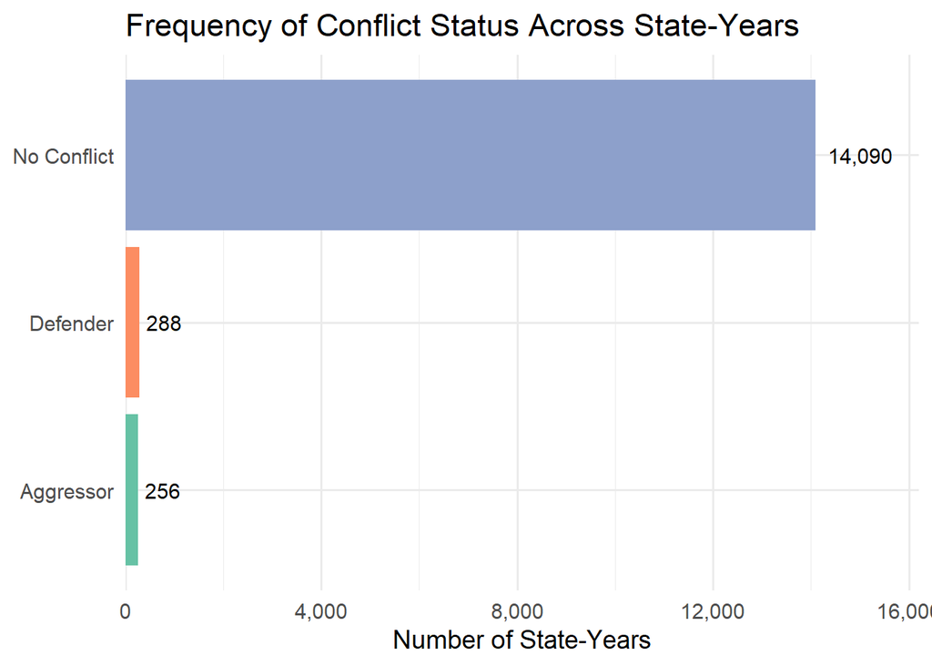

```r
AnalysisData |>
  mutate(Status = case_when(
    IsDefender  == 1 ~ "Defender",
    IsAggressor == 1 ~ "Aggressor",
    TRUE             ~ "No Conflict"
  )) |>
  count(Status) |>
  mutate(Status = fct_reorder(Status, n)) |>
  ggplot(aes(x = Status, y = n, fill = Status)) +
  geom_col(show.legend = FALSE) +
  geom_text(aes(label = scales::comma(n)), hjust = -0.2, size = 4) +
  coord_flip() +
  scale_fill_brewer(palette = "Set2") +
  scale_y_continuous(labels = scales::comma,
                     expand = expansion(mult = c(0, 0.15))) +
  labs(title = "Frequency of Conflict Status Across State-Years",
       x = NULL, y = "Number of State-Years") +
  theme_minimal(base_size = 14)
```

The extreme imbalance between conflict and no-conflict observations is immediately apparent. The rare-event nature of interstate conflict is a reality of the international system, and it shapes every modelling and evaluation decision that follows.

## 3.3 Key Variable Distributions

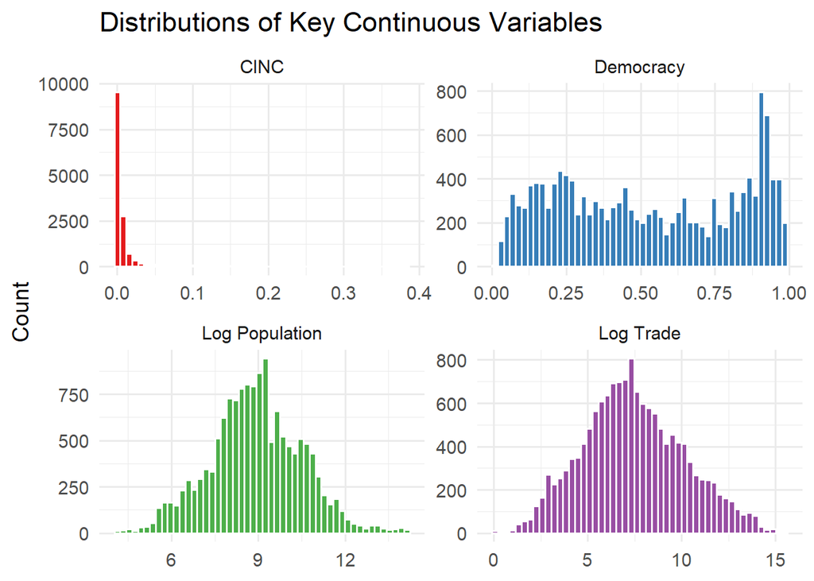

```r
AnalysisData |>
  select(cinc, democracy, LogTrade, LogPop) |>
  rename(CINC = cinc, Democracy = democracy,
         `Log Trade` = LogTrade, `Log Population` = LogPop) |>
  pivot_longer(everything(), names_to = "Variable", values_to = "Value") |>
  ggplot(aes(x = Value, fill = Variable)) +
  geom_histogram(bins = 50, color = "white", show.legend = FALSE) +
  facet_wrap(~Variable, scales = "free", ncol = 2) +
  scale_fill_brewer(palette = "Set1") +
  labs(title = "Distributions of Key Continuous Variables",
       x = NULL, y = "Count") +
  theme_minimal(base_size = 14)
```

CINC is extremely right-skewed: the distribution is dominated by states near zero, with a long tail toward the few major powers. At first glance, it appears necessary to log transform CINC. However, CINC is a proportion and the skew is substantively meaningful. The skew reflects real concentration of power in the international system.

However, Log-transforming trade and population produces approximately bell-shaped densities suited to linear modelling. Democracy shows a bimodal pattern with modes near both the authoritarian and democratic poles, suggesting that the international system clusters at regime-type extremes rather than distributing continuously.

## 3.4 Key Variables by Conflict Status

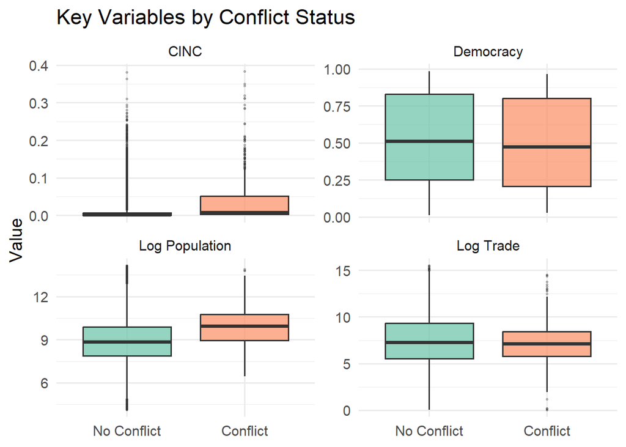

```r
AnalysisData |>
  mutate(Conflict = factor(ConflictParticipation,
                           labels = c("No Conflict", "Conflict"))) |>
  select(Conflict, cinc, democracy, LogTrade, LogPop) |>
  rename(CINC = cinc, Democracy = democracy,
         `Log Trade` = LogTrade, `Log Population` = LogPop) |>
  pivot_longer(-Conflict, names_to = "Variable", values_to = "Value") |>
  ggplot(aes(x = Conflict, y = Value, fill = Conflict)) +
  geom_boxplot(alpha = 0.7, show.legend = FALSE,
               outlier.size = 0.5, outlier.alpha = 0.3) +
  facet_wrap(~Variable, scales = "free_y", ncol = 2) +
  scale_fill_brewer(palette = "Set2") +
  labs(title = "Key Variables by Conflict Status",
       x = NULL, y = "Value") +
  theme_minimal(base_size = 14)
```

The box plot begins to reveal the direction of relationships before modeling. The CINC panel in particular is interesting, states that participated in conflict have tend to have higher capabilities scores. This is a preliminary sign that capability and conflict are related in a way opposed to deterrence theory. Log-population tells a similar story with states experiencing conflict clustering at higher values. On the other hand, log-trade and democracy show smaller differences between conflict groups.

## 3.5 Correlation Structure

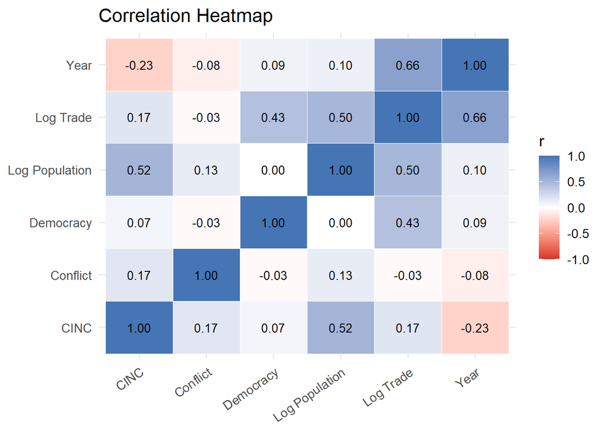

```r
cor_vars <- AnalysisData |>
  select(cinc, democracy, LogTrade, LogPop, year,
         ConflictParticipation) |>
  rename(CINC = cinc, Democracy = democracy, `Log Trade` = LogTrade,
         `Log Population` = LogPop, `Year` = year,
         Conflict = ConflictParticipation)

cor_matrix <- round(cor(cor_vars, use = "complete.obs"), 3)

cor_matrix |>
  as.data.frame() |>
  tibble::rownames_to_column("Var1") |>
  pivot_longer(-Var1, names_to = "Var2", values_to = "Correlation") |>
  ggplot(aes(x = Var1, y = Var2, fill = Correlation)) +
  geom_tile(color = "white") +
  geom_text(aes(label = sprintf("%.2f", Correlation)), size = 3.5) +
  scale_fill_gradient2(low = "#d73027", mid = "white", high = "#4575b4",
                       midpoint = 0, limits = c(-1, 1)) +
  labs(title = "Correlation Heatmap", x = NULL, y = NULL, fill = "r") +
  theme_minimal(base_size = 13) +
  theme(axis.text.x = element_text(angle = 35, hjust = 1))
```

CINC is positively correlated with conflict participation (r = 0.17), however this appears to be a minimal effect. The correlation between log-trade and democracy(r = 0.43) is moderate, but warrants further investigation.

We also see a very high correlation between year and log-trade (0.661) showing that trade has increased over time. We also see correlations between year and CINC (-0.227) This lends credence to including the year term to any model as without it other terms may absorb temporal trends.

None of the predictor correlations are high enough to signal a multicollinearity concern in the models (besides year & log-trade). Multicollinearity will be assessed formally via VIF in the diagnostics section.

## 3.6 Temporal Trends

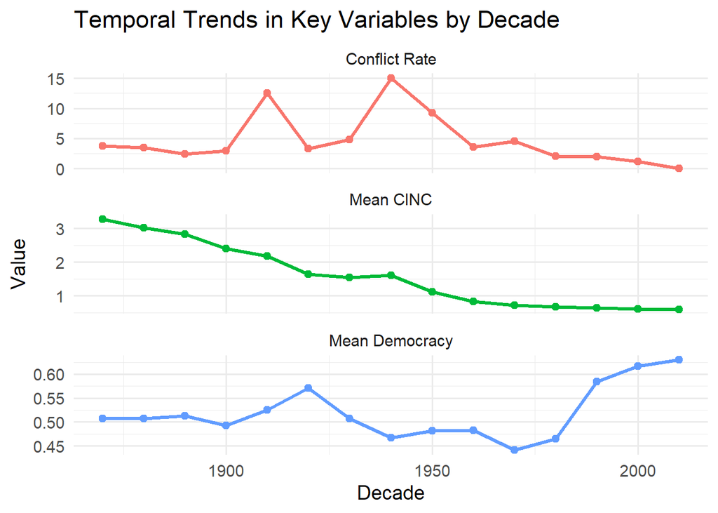

```r
AnalysisData |>
  mutate(decade = floor(year / 10) * 10) |>
  group_by(decade) |>
  summarise(
    N = n(),
    `Conflict Rate`  = mean(ConflictParticipation) * 100,
    `Mean CINC`      = mean(cinc) * 100,
    `Mean Democracy` = mean(democracy),
    .groups = "drop"
  ) |>
  pivot_longer(cols = c(`Conflict Rate`, `Mean CINC`, `Mean Democracy`),
               names_to = "Variable", values_to = "Value") |>
  ggplot(aes(x = decade, y = Value, color = Variable)) +
  geom_line(linewidth = 1.2) +
  geom_point(size = 2) +
  facet_wrap(~Variable, scales = "free_y", ncol = 1) +
  labs(title = "Temporal Trends in Key Variables by Decade",
       x = "Decade", y = "Value") +
  theme_minimal(base_size = 14) +
  theme(legend.position = "none")
```

Conflict rates spike around the World Wars and decline in the post-Cold War era. Democracy levels rise sharply after 1990. CINC distributions reflect the rise and fall of major powers.These trends confirm that year is both a necessary control and a variable of interest in its own right.

## 3.7 Conflict Rates by Military Capability Quartile

```r
cincsum <- AnalysisData |>
  mutate(cinc_quartile = cut(cinc,
    breaks = quantile(cinc, probs = c(0, 0.25, 0.5, 0.75, 1)),
    labels = c("Q1 (Lowest)", "Q2", "Q3", "Q4 (Highest)"),
    include.lowest = TRUE)) |>
  group_by(cinc_quartile) |>
  summarise(
    N                = n(),
    `Conflict Rate`  = round(mean(ConflictParticipation) * 100, 2),
    `Defender Rate`  = round(mean(IsDefender)            * 100, 2),
    `Aggressor Rate` = round(mean(IsAggressor)           * 100, 2),
    .groups = "drop")

cincsum |> knitr::kable(caption = "Conflict Rates (%) by CINC Quartile")
```

Conflict Rates (%) by CINC Quartile

| cinc_quartile | N | Conflict Rate | Defender Rate | Aggressor Rate |
| --- | --- | --- | --- | --- |
| Q1 (Lowest) | 3659 | 0.36 | 0.11 | 0.25 |
| Q2 | 3658 | 2.38 | 1.39 | 0.96 |
| Q3 | 3659 | 4.54 | 2.21 | 2.08 |
| Q4 (Highest) | 3658 | 8.64 | 4.16 | 3.72 |

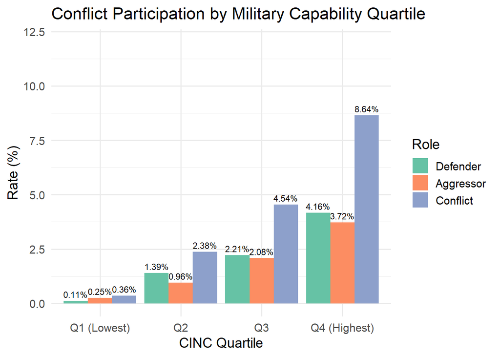

```r
cincsum |>
  pivot_longer(cols = ends_with("Rate"), names_to = "Type", values_to = "Rate") |>
  mutate(Type = str_remove(Type, " Rate"),
         Type = factor(Type, levels = c("Defender", "Aggressor", "Conflict"))) |>
  ggplot(aes(x = cinc_quartile, y = Rate, fill = Type)) +
  geom_col(position = "dodge") +
  geom_text(aes(label = paste0(Rate, "%")),
            position = position_dodge(width = 0.9), vjust = -0.5, size = 3) +
  labs(title = "Conflict Participation by Military Capability Quartile",
       x = "CINC Quartile", y = "Rate (%)", fill = "Role") +
  theme_minimal(base_size = 14) +
  scale_fill_brewer(palette = "Set2") +
  ylim(0, 12)
```

Conflict participation rises with military capability across all roles. States in the highest CINC quartile have a conflict rate of 8.64%, compared to just 0.36% for states in the lowest quartile. A very interesting pattern arises, defenders experience higher conflict rates than aggressors in nearly every CINC quartile. Perhaps an aggressor may be triggering large wars with alliances, any further work beyond this project will include a measure of if a State is joining a conflict as the primary or ally.

# 4 Logistic Regression

## 4.1 Model Specification

Three nested logistic regression models are estimated, progressing from a baseline to the theoretically motivated full specification:

- Model 1: ConflictParticipation ~ CINC
- Model 2: Model 1 + LogTrade$_C$ + Democracy$_C$ + LogPop + Year$_C$
- Model 3: Model 2 + Democracy$_C$ $\times$ LogTrade$_C$

Model 3 extends Model 2 with a centered democracy × trade interaction term, testing the liberal peace proposition that trade’s conflict-reducing effect is amplified by democratic governance. An uncentered version (`logitMOD3_uc`) is estimated separately and used only for the VIF comparison in the diagnostics section.

## 4.2 Model Estimation

```r
logitMOD1 <- glm(ConflictParticipation ~ cinc,
                 data = AnalysisData, family = binomial(link = "logit"))

logitMOD2 <- glm(ConflictParticipation ~ cinc + LogTradeCentered + DemocracyCentered +
                   LogPop + YearCentered,
                 data = AnalysisData, family = binomial(link = "logit"))

logitMOD3 <- glm(ConflictParticipation ~ cinc + LogTradeCentered + DemocracyCentered +
                   LogPop + YearCentered + DemocracyCentered:LogTradeCentered,
                 data = AnalysisData, family = binomial(link = "logit"))

# Uncentered - used only for VIF comparison in diagnostics
logitMOD3_uc <- glm(ConflictParticipation ~ cinc + LogTrade + democracy +
                      LogPop + YearCentered + democracy * LogTrade,
                    data = AnalysisData, family = binomial(link = "logit"))
```

```r
stargazer(logitMOD1, logitMOD2, logitMOD3,
          type = "html",
          title = "Logistic Regression Results",
          dep.var.labels = "Conflict Participation",
          covariate.labels = c("CINC", "Trade (log, centered)",
                               "Democracy (centered)",
                               "Population (log)", "Year (centered)",
                               "Democracy \u00d7 Trade"),
          column.labels = c("Model 1", "Model 2", "Model 3"),
          model.numbers = FALSE,
          star.cutoffs = c(0.05, 0.01, 0.001),
          omit.stat = c("aic"))
```

**Logistic Regression Results**

|  | *Dependent variable:* |  |  |
| --- | --- | --- | --- |
|  | Conflict Participation |  |  |
|  | Model 1 | Model 2 | Model 3 |
| CINC | 12.040*** | 5.546*** | 5.638*** |
|  | (0.705) | (1.065) | (1.066) |
| Trade (log, centered) |  | -0.284*** | -0.288*** |
|  |  | (0.036) | (0.036) |
| Democracy (centered) |  | 0.478* | 0.497** |
|  |  | (0.193) | (0.190) |
| Population (log) |  | 0.526*** | 0.522*** |
|  |  | (0.041) | (0.041) |
| Year (centered) |  | 0.001 | 0.001 |
|  |  | (0.002) | (0.002) |
| Democracy × Trade |  |  | -0.138* |
|  |  |  | (0.062) |
| Constant | -3.431*** | -8.257*** | -8.189*** |
|  | (0.048) | (0.390) | (0.391) |
| Observations | 14,634 | 14,634 | 14,634 |
| Log Likelihood | -2,334.295 | -2,222.615 | -2,220.071 |
| *Note:* | *p<0.05; **p<0.01;*** p<0.001 |  |  |

CINC is positive and strongly significant across all three models. In Model 1, the bivariate log-odds coefficient is 12.04. Adding log-trade, democracy, log-population, and year in Model 2 reduces it to 5.55 - a shrinkage of roughly 54%. This attenuation indicates omitted-variable bias in the bivariate estimate: more capable states are also more populous and economically integrated, and omitting these covariates inflates the raw CINC coefficient. Even after controls, the effect remains large and positive, opposite to what deterrence theory predicts.

The full-scale odds ratio for CINC in Model 3 is 281, representing conflict odds across the entire 0–1 CINC range. No state traverses that range in practice, so a one standard deviation shift is more interpretable. With SD = 0.0321, a one-SD increase in CINC corresponds to an odds ratio of 1.2 - conflict odds rise by roughly 20% per standard deviation.

The controls behave consistently with the literature. Log-population carries a strong positive coefficient (OR $\approx$ 1.69). Log-trade is negative (OR $\approx$ 0.75), supporting the liberal peace claim that economic integration dampens conflict. The democracy $\times$ trade interaction is negative (OR = 0.8711, p = 0.0259), directionally consistent with liberal peace theory, though its significance under clustering is evaluated below. However, a very surprising outcome is the democracy coefficient: 0.497. This suggests democracies may be more likely to participate in conflict. Perhaps democratic regimes are more likely to defend other democratic regimes? Again, my future work will include a measure of if a State is joining a conflict as the primary defender or aggressor, or as an ally.

## 4.3 Clustered Standard Errors

```r
logit3_clustered <- coeftest(
  logitMOD3,
  vcov = vcovCL(logitMOD3, cluster = AnalysisData$StateNme)
)

logit3_clustered |>
  unclass() |>
  as.data.frame() |>
  tibble::rownames_to_column("Term") |>
  mutate(across(where(is.numeric), ~round(., 4))) |>
  knitr::kable(caption = "Logistic Model 3 - Standard Errors Clustered by State")
```

Logistic Model 3 - Standard Errors Clustered by State

| Term | Estimate | Std. Error | z value | Pr(>\|z\|) |
| --- | --- | --- | --- | --- |
| (Intercept) | -8.1887 | 0.7908 | -10.3549 | 0.0000 |
| cinc | 5.6383 | 1.8115 | 3.1124 | 0.0019 |
| LogTradeCentered | -0.2883 | 0.0815 | -3.5364 | 0.0004 |
| DemocracyCentered | 0.4966 | 0.5026 | 0.9881 | 0.3231 |
| LogPop | 0.5220 | 0.0824 | 6.3316 | 0.0000 |
| YearCentered | 0.0014 | 0.0036 | 0.3892 | 0.6972 |
| LogTradeCentered:DemocracyCentered | -0.1380 | 0.1426 | -0.9678 | 0.3331 |

Because my curated dataset is essentially panel data of the same States being observed at different times, we are violating assumptions of independence. Therefore, to better interpret our model we need to cluster the standard errors by State. I did this using the `sandwich` package’s `vcovCL()` function. You can see this process and the results above.

Clustering shifts the picture for some coefficients. CINC remains strongly significant (z = 3.11, p = 0.00186), as do log-population and log-trade. Democracy and the democracy $\times$ trade interaction both lose significance under clustering (p = 0.323 and p = 0.333, respectively). Once within-state correlation is accounted for, the interaction term becomes insignificant.

## 4.4 Role-Specific Analysis

Deterrence theory predicts capable states should be less likely to be *attacked*; it says little about whether capable states *initiate* conflict. Parallel models for defender and aggressor status allow a sharper, role-specific test of the deterrence mechanism.

```r
defenderMOD <- glm(IsDefender ~ cinc + LogTradeCentered + DemocracyCentered +
                     LogPop + YearCentered + DemocracyCentered * LogTradeCentered,
                   data = AnalysisData, family = binomial(link = "logit"))

aggressorMOD <- glm(IsAggressor ~ cinc + LogTradeCentered + DemocracyCentered +
                      LogPop + YearCentered + DemocracyCentered * LogTradeCentered,
                    data = AnalysisData, family = binomial(link = "logit"))


#Cluster SE:

vcov_def <- vcovCL(defenderMOD, cluster = ~StateNme)
vcov_agg <- vcovCL(aggressorMOD, cluster = ~StateNme)

se_def <- sqrt(diag(vcov_def))
se_agg <- sqrt(diag(vcov_agg))
```

```r
se_logit3 <- sqrt(diag(vcovCL(logitMOD3, cluster = ~StateNme)))


stargazer(defenderMOD, aggressorMOD, logitMOD3,
          type = "html",
          se = list(se_def, se_agg, se_logit3),
          title = "Logistic Regression by Conflict Role",
          dep.var.labels = c("Defender", "Aggressor", "Any Conflict"),
          covariate.labels = c("CINC", "Trade (log, centered)",
                               "Democracy (centered)",
                               "Population (log)", "Year (centered)",
                               "Democracy \u00d7 Trade"),
          model.numbers = FALSE,
          star.cutoffs = c(0.05, 0.01, 0.001),
          omit.stat = c("aic"),
          notes = "Clustered standard errors by country (StateNme).")
```

**Logistic Regression by Conflict Role**

|  | *Dependent variable:* |  |  |
| --- | --- | --- | --- |
|  | Defender | Aggressor | Any Conflict |
| CINC | 3.885 | 6.229** | 5.638** |
|  | (2.537) | (2.299) | (1.812) |
| Trade (log, centered) | -0.267* | -0.241* | -0.288*** |
|  | (0.111) | (0.100) | (0.082) |
| Democracy (centered) | 0.440 | 0.440 | 0.497 |
|  | (0.625) | (0.644) | (0.503) |
| Population (log) | 0.510*** | 0.433*** | 0.522*** |
|  | (0.099) | (0.105) | (0.082) |
| Year (centered) | 0.001 | 0.001 | 0.001 |
|  | (0.005) | (0.005) | (0.004) |
| Democracy × Trade | -0.163 | -0.072 | -0.138 |
|  | (0.155) | (0.192) | (0.143) |
| Constant | -8.760*** | -8.222*** | -8.189*** |
|  | (0.932) | (1.048) | (0.791) |
| Observations | 14,634 | 14,634 | 14,634 |
| Log Likelihood | -1,315.133 | -1,200.821 | -2,220.071 |
| *Note:* | *p<0.05; **p<0.01;*** p<0.001 |  |  |
|  | Clustered standard errors by country (StateNme). |  |  |

# 5 Model Comparison and Selection

## 5.1 Fit Statistics

```r
tibble(
  Model            = c("Model 1", "Model 2", "Model 3"),
  AIC              = c(AIC(logitMOD1), AIC(logitMOD2), AIC(logitMOD3)),
  BIC              = c(BIC(logitMOD1), BIC(logitMOD2), BIC(logitMOD3)),
  `Log-Likelihood` = c(ll1, ll2, ll3),
  Deviance         = c(deviance(logitMOD1), deviance(logitMOD2), deviance(logitMOD3))
) |>
  mutate(across(where(is.numeric), ~round(., 1))) |>
  knitr::kable(caption = "Logistic Model Fit Statistics")
```

Logistic Model Fit Statistics

| Model | AIC | BIC | Log-Likelihood | Deviance |
| --- | --- | --- | --- | --- |
| Model 1 | 4672.6 | 4687.8 | -2334.3 | 4668.6 |
| Model 2 | 4457.2 | 4502.8 | -2222.6 | 4445.2 |
| Model 3 | 4454.1 | 4507.3 | -2220.1 | 4440.1 |

## 5.2 Likelihood Ratio Tests

```r
lr_1v2 <- anova(logitMOD1, logitMOD2, test = "LRT")
lr_2v3 <- anova(logitMOD2, logitMOD3, test = "LRT")

tibble(
  Comparison   = c("Model 1 vs. Model 2", "Model 2 vs. Model 3"),
  `Chi-Square` = c(round(lr_1v2$Deviance[2], 2), round(lr_2v3$Deviance[2], 2)),
  df           = c(lr_1v2$Df[2], lr_2v3$Df[2]),
  `p-value`    = c(
    format.pval(lr_1v2$`Pr(>Chi)`[2], digits = 4),
    format.pval(lr_2v3$`Pr(>Chi)`[2], digits = 4)
  )
) |>
  knitr::kable(caption = "Likelihood Ratio Tests")
```

Likelihood Ratio Tests

| Comparison | Chi-Square | df | p-value |
| --- | --- | --- | --- |
| Model 1 vs. Model 2 | 223.36 | 4 | < 2.2e-16 |
| Model 2 vs. Model 3 | 5.09 | 1 | 0.02408 |

Model 2 dramatically improves on the bivariate Model 1 ($\chi^2$ = 223.4, p < 0.001), confirming that the controls jointly explain substantial variation in conflict probability. The step from Model 2 to Model 3 is also statistically significant ($\chi^2$ = 5.09, p = 0.024) in likelihood ratio terms, though BIC slightly penalizes Model 3 for the added parameter and the resulting complexity. Model 3 does have the lowest AIC and Deviance.

## 5.3 Brier Score and Cross-Validated AUC

The PRESS statistic, a standard OLS model comparison tool, does not apply directly to logistic regression because GLM residuals operate in log-odds space rather than in the outcome’s natural units. Two logistic-appropriate substitutes are used instead. The Brier score is the mean squared error between predicted probabilities and observed binary outcomes - it is bounded $[0, 1]$, with lower values indicating better calibration. Cross-validated AUC is estimated via five-fold cross-validation, providing an assessment that guards against overfitting.

```r
brier <- function(model, data, outcome) {
  p <- predict(model, newdata = data, type = "response")
  y <- data[[outcome]]
  mean((y - p)^2)
}

brier1 <- round(brier(logitMOD1, AnalysisData, "ConflictParticipation"), 5)
brier2 <- round(brier(logitMOD2, AnalysisData, "ConflictParticipation"), 5)
brier3 <- round(brier(logitMOD3, AnalysisData, "ConflictParticipation"), 5)
```

```r
set.seed(123)
k       <- 5
folds   <- sample(rep(1:k, length.out = nrow(AnalysisData)))
cv_aucs <- matrix(NA, nrow = k, ncol = 3)

for (i in 1:k) {
  train <- AnalysisData[folds != i, ]
  test  <- AnalysisData[folds == i, ]

  m1 <- glm(ConflictParticipation ~ cinc,
            data = train, family = binomial(link = "logit"))
  m2 <- glm(ConflictParticipation ~ cinc + LogTradeCentered + DemocracyCentered +
              LogPop + YearCentered,
            data = train, family = binomial(link = "logit"))
  m3 <- glm(ConflictParticipation ~ cinc + LogTradeCentered + DemocracyCentered +
              LogPop + YearCentered + DemocracyCentered:LogTradeCentered,
            data = train, family = binomial(link = "logit"))

  cv_aucs[i, 1] <- as.numeric(auc(roc(test$ConflictParticipation,
                     predict(m1, test, type = "response"), quiet = TRUE)))
  cv_aucs[i, 2] <- as.numeric(auc(roc(test$ConflictParticipation,
                     predict(m2, test, type = "response"), quiet = TRUE)))
  cv_aucs[i, 3] <- as.numeric(auc(roc(test$ConflictParticipation,
                     predict(m3, test, type = "response"), quiet = TRUE)))
}

cv_auc1 <- round(mean(cv_aucs[, 1]), 3)
cv_auc2 <- round(mean(cv_aucs[, 2]), 3)
cv_auc3 <- round(mean(cv_aucs[, 3]), 3)
```

```r
tibble(
  Model           = c("Model 1", "Model 2", "Model 3"),
  AIC             = round(c(AIC(logitMOD1), AIC(logitMOD2), AIC(logitMOD3)), 1),
  BIC             = round(c(BIC(logitMOD1), BIC(logitMOD2), BIC(logitMOD3)), 1),
  `Brier Score`   = c(brier1, brier2, brier3),
  `5-Fold CV AUC` = c(cv_auc1, cv_auc2, cv_auc3)
) |>
  knitr::kable(
    caption = "Model Comparison: Fit, Calibration, and Out-of-Sample Discrimination"
  )
```

Model Comparison: Fit, Calibration, and Out-of-Sample Discrimination

| Model | AIC | BIC | Brier Score | 5-Fold CV AUC |
| --- | --- | --- | --- | --- |
| Model 1 | 4672.6 | 4687.8 | 0.03739 | 0.739 |
| Model 2 | 4457.2 | 4502.8 | 0.03685 | 0.748 |
| Model 3 | 4454.1 | 4507.3 | 0.03687 | 0.750 |

Across every metric, Model 1 is the weakest specification. Models 2 and 3 are closely competitive: both reduce Brier score relative to Model 1 and achieve CV AUC values of 0.748 and 0.75 respectively, indicating the performance improvement from adding controls increases predictive power beyond the training data. BIC favours Model 2 because it penalizes the added interaction parameter more heavily. Because the interaction also fails clustering and BIC points toward the simpler specification, Model 2 is the preferred model for substantive inference. Model 3 is retained as the primary diagnostic specification given its greater complexity.

## 5.4 Final Model Selection

Model 2 is the preferred substantive model because it models a binary outcome with the logit link the closest, includes theoretically motivated controls that reduce omitted-variable bias, its CINC coefficient survives state-level clustering, and BIC prefers it over the more complex Model 3. The interaction term in Model 3 is directionally consistent with liberal peace theory but does not achieve significance in the clustered specification and therefore does not meet the threshold for inclusion in the preferred model. All hypothesis testing below references Model 3 as the most complete specification; however, if my goal was to make the best *predictive* model, model 2 would be my preferred choice. Because Model 3 one hypothesis necessitates the inclusion of an interaction term, I will run diagnostics on Model 3.

# 6 Regression Diagnostics

Diagnostics are conducted on Model 3, the most complex specification, which provides the most complete residual picture. All results are interpreted in light of the binary outcome and the rare-event nature of interstate conflict.

```r
AnalysisData <- AnalysisData |>
  mutate(
    fitted_prob    = fitted(logitMOD3),
    deviance_resid = residuals(logitMOD3, type = "deviance"),
    pearson_resid  = residuals(logitMOD3, type = "pearson"),
    working_resid  = residuals(logitMOD3, type = "working")
  )
```

## 6.1 Pearson Residuals vs. Linear Predictor

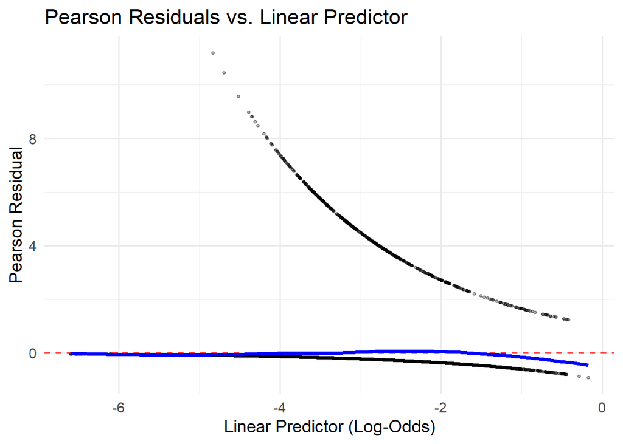

```r
AnalysisData <- AnalysisData |>
  mutate(linear_pred = predict(logitMOD3, type = "link"))

ggplot(AnalysisData, aes(x = linear_pred, y = pearson_resid)) +
  geom_point(alpha = 0.3, size = 0.8) +
  geom_hline(yintercept = 0, linetype = "dashed", color = "red") +
  geom_smooth(method = "loess", se = FALSE, color = "blue") +
  labs(title = "Pearson Residuals vs. Linear Predictor",
       x = "Linear Predictor (Log-Odds)", y = "Pearson Residual") +
  theme_minimal(base_size = 14)
```

The LOESS line remains near zero throughout most of the log-odds range, confirming that the logit link captures the relationship appropriately. Slight deviation at extreme values reflects the difficulty of modelling conflict cases at very high predicted probabilities.

## 6.2 Binned Residual Plot

For binary outcomes, binned residuals are more informative than raw scatterplots. Observations are grouped into 20 bins by fitted probability and the mean residual per bin is plotted with 95% error bars.

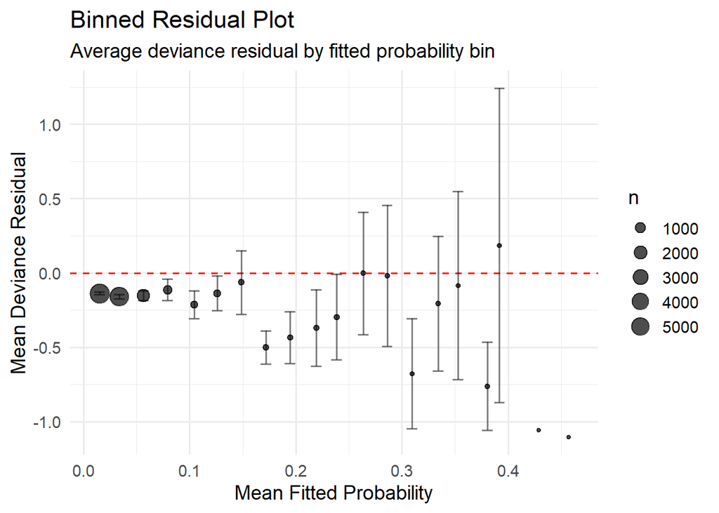

```r
binned_data <- AnalysisData |>
  mutate(prob_bin = cut(fitted_prob, breaks = 20)) |>
  group_by(prob_bin) |>
  summarise(
    mean_fitted = mean(fitted_prob),
    mean_resid  = mean(deviance_resid),
    se_resid    = sd(deviance_resid) / sqrt(n()),
    n = n(),
    .groups = "drop"
  ) |>
  filter(!is.na(prob_bin))

ggplot(binned_data, aes(x = mean_fitted, y = mean_resid)) +
  geom_point(aes(size = n), alpha = 0.7) +
  geom_hline(yintercept = 0, linetype = "dashed", color = "red") +
  geom_errorbar(aes(ymin = mean_resid - 2 * se_resid,
                    ymax = mean_resid + 2 * se_resid),
                width = 0.01, alpha = 0.5) +
  labs(title = "Binned Residual Plot",
       subtitle = "Average deviance residual by fitted probability bin",
       x = "Mean Fitted Probability", y = "Mean Deviance Residual", size = "n") +
  theme_minimal(base_size = 14)
```

## 6.3 Multicollinearity

```r
vif(logitMOD3_uc) |>
  enframe(name = "Variable", value = "VIF") |>
  mutate(VIF = round(VIF, 2),
         Assessment = case_when(
           VIF < 5  ~ "Acceptable",
           VIF < 10 ~ "Moderate",
           TRUE     ~ "High"
         )) |>
  knitr::kable(caption = "VIF - Logistic Model 3, Uncentered Variables (For Demonstrative Purposes Only)")
```

VIF - Logistic Model 3, Uncentered Variables (For Demonstrative Purposes Only)

| Variable | VIF | Assessment |
| --- | --- | --- |
| cinc | 2.10 | Acceptable |
| LogTrade | 6.76 | Moderate |
| democracy | 11.09 | High |
| LogPop | 2.67 | Acceptable |
| YearCentered | 2.71 | Acceptable |
| LogTrade:democracy | 16.58 | High |

```r
vif(logitMOD3) |>
  enframe(name = "Variable", value = "VIF") |>
  mutate(VIF = round(VIF, 2),
         Assessment = case_when(
           VIF < 5  ~ "Acceptable",
           VIF < 10 ~ "Moderate",
           TRUE     ~ "High"
         )) |>
  knitr::kable(caption = "VIF - Logistic Model 3, Centered Variables")
```

VIF - Logistic Model 3, Centered Variables

| Variable | VIF | Assessment |
| --- | --- | --- |
| cinc | 2.10 | Acceptable |
| LogTradeCentered | 4.05 | Acceptable |
| DemocracyCentered | 1.57 | Acceptable |
| LogPop | 2.67 | Acceptable |
| YearCentered | 2.71 | Acceptable |
| LogTradeCentered:DemocracyCentered | 1.01 | Acceptable |

The uncentered specification shows elevated VIF for democracy, log-trade, and especially the interaction term, a consequence of the product term correlating with its components. Centering before forming the interaction substantially reduces these values, validating the centering approach. The multicollinearity is mathematical in origin and not a flaw in the specification.

## 6.4 Cook’s Distance

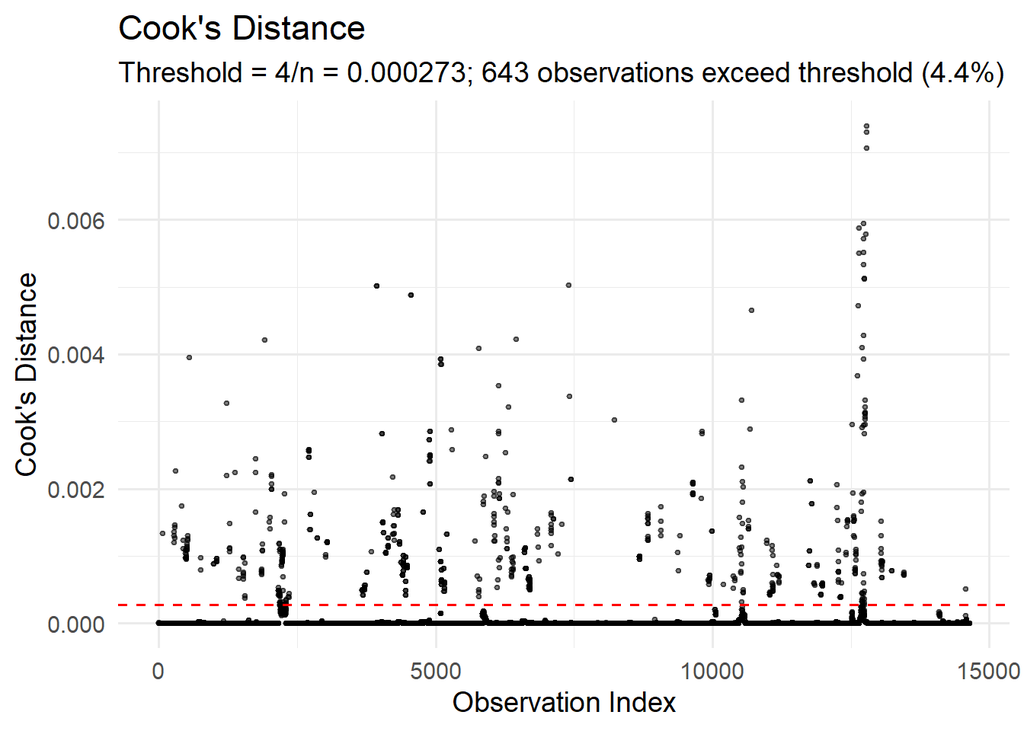

```r
AnalysisData <- AnalysisData |>
  mutate(cooks_d = cooks.distance(logitMOD3))

threshold     <- 4 / nrow(AnalysisData)
n_influential <- sum(AnalysisData$cooks_d > threshold)

ggplot(AnalysisData, aes(x = seq_along(cooks_d), y = cooks_d)) +
  geom_point(alpha = 0.5, size = 0.8) +
  geom_hline(yintercept = threshold, linetype = "dashed", color = "red") +
  labs(title = "Cook's Distance",
       subtitle = paste0("Threshold = 4/n = ", round(threshold, 6),
                         "; ", n_influential, " observations exceed threshold (",
                         round(n_influential / nrow(AnalysisData) * 100, 1), "%)"),
       x = "Observation Index", y = "Cook's Distance") +
  theme_minimal(base_size = 14)
```

```r
AnalysisData |>
  arrange(desc(cooks_d)) |>
  head(10) |>
  select(StateNme, year, ConflictParticipation, cinc, cooks_d) |>
  mutate(cooks_d = round(cooks_d, 5)) |>
  knitr::kable(caption = "10 Most Influential Observations")
```

10 Most Influential Observations

| StateNme | year | ConflictParticipation | cinc | cooks_d |
| --- | --- | --- | --- | --- |
| United States of America | 2003 | 1 | 0.1517724 | 0.00740 |
| United States of America | 2001 | 1 | 0.1414117 | 0.00731 |
| United States of America | 1999 | 1 | 0.1425080 | 0.00707 |
| United States of America | 1945 | 1 | 0.3838635 | 0.00595 |
| United Kingdom | 2003 | 1 | 0.0191416 | 0.00588 |
| United States of America | 1991 | 1 | 0.1371378 | 0.00579 |
| United States of America | 1944 | 1 | 0.3506417 | 0.00572 |
| United States of America | 1943 | 1 | 0.3456322 | 0.00551 |
| United Kingdom | 2001 | 1 | 0.0213447 | 0.00550 |
| United States of America | 1951 | 1 | 0.3194995 | 0.00534 |

The maximum Cook’s distance ($\approx$ 0.007) is far below conventional concern thresholds of 0.5 or 1. The most influential observations are predominantly US state-years during major conflicts - World War II, the Gulf War, the Iraq War. These are extreme but genuine cases, meaning, their influence is expected rather than a diagnostic of data errors.

## 6.5 ROC Curve

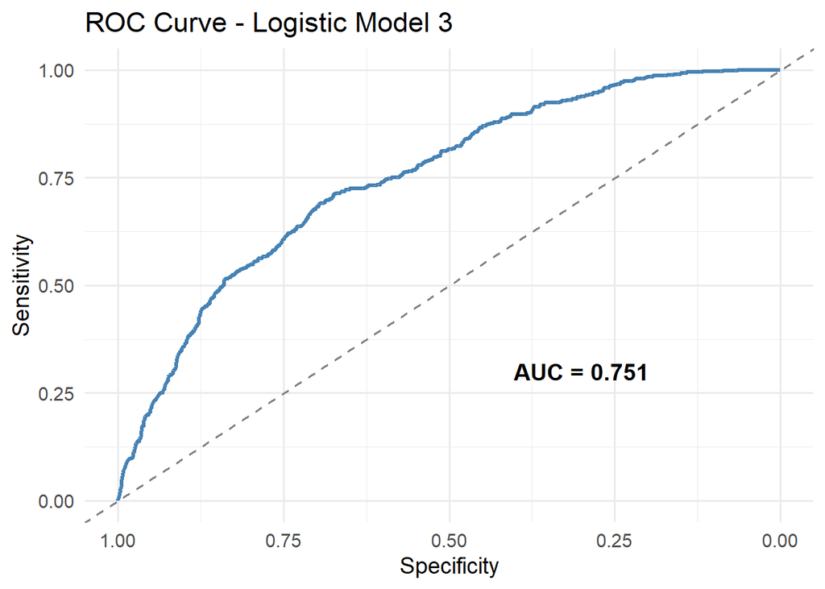

```r
rocnum  <- roc(AnalysisData$ConflictParticipation, fitted(logitMOD3), quiet = TRUE)
auc_val <- round(auc(rocnum), 3)

ggroc(rocnum, linewidth = 1.2, color = "steelblue") +
  geom_abline(intercept = 1, slope = 1, linetype = "dashed", color = "gray50") +
  annotate("text", x = 0.3, y = 0.3,
           label = paste("AUC =", auc_val), size = 5, fontface = "bold") +
  labs(title = "ROC Curve - Logistic Model 3",
       x = "Specificity", y = "Sensitivity") +
  theme_minimal(base_size = 14)
```

The in-sample AUC of 0.751 falls in the acceptable discrimination range of 0.7–0.8. The five-fold cross-validated AUC of 0.75 confirms this performance generalizes beyond the training data. For an outcome comprising only 4% of state-years, this represents reasonable discrimination. These models are built for inference rather than prediction; the AUC and Brier score serve as secondary indicators of model coherence and calibration.

# 7 Hypothesis Testing Results

## 7.1 Primary Hypothesis: Total Deterrence

As you can see below, all interpretation will be done with the *clustered* Model 3, meaning we are accounting for the within-state variation.

```r
h1_coef    <- round(logit3_clustered["cinc", "Estimate"], 4)
h1_se      <- round(logit3_clustered["cinc", "Std. Error"], 4)
h1_z       <- round(logit3_clustered["cinc", "z value"], 3)
h1_p       <- format.pval(logit3_clustered["cinc", "Pr(>|z|)"], digits = 4)
h1_or      <- round(exp(logit3_clustered["cinc", "Estimate"]), 2)
h1_ci_low  <- round(exp(logit3_clustered["cinc", "Estimate"] -
                          1.96 * logit3_clustered["cinc", "Std. Error"]), 2)
h1_ci_high <- round(exp(logit3_clustered["cinc", "Estimate"] +
                          1.96 * logit3_clustered["cinc", "Std. Error"]), 2)

data.frame(
  Statistic = c("Coefficient (log-odds)", "Std. Error", "z value",
                "p-value", "Odds Ratio", "95% CI (clustered)"),
  Value     = c(h1_coef, h1_se, h1_z, h1_p, h1_or,
                paste0("[", h1_ci_low, ", ", h1_ci_high, "]"))
) |>
  knitr::kable(
    col.names = c("Statistic", "Value"),
    caption   = "CINC Coefficient Summary - Logistic Model 3 (Clustered SEs)",
    align     = c("l", "r")
  )
```

CINC Coefficient Summary - Logistic Model 3 (Clustered SEs)

| Statistic | Value |
| --- | --- |
| Coefficient (log-odds) | 5.6383 |
| Std. Error | 1.8115 |
| z value | 3.112 |
| p-value | 0.001855 |
| Odds Ratio | 280.99 |
| 95% CI (clustered) | [8.07, 9788.06] |

## 7.2 Role-Specific Deterrence

```r
def_clustered <- coeftest(defenderMOD,
                          vcov = vcovCL(defenderMOD, cluster = AnalysisData$StateNme))
agg_clustered <- coeftest(aggressorMOD,
                          vcov = vcovCL(aggressorMOD, cluster = AnalysisData$StateNme))

def_coef <- round(def_clustered["cinc", "Estimate"], 4)
def_or   <- round(exp(def_clustered["cinc", "Estimate"]), 2)
def_p_ht <- round(def_clustered["cinc", "Pr(>|z|)"], 4)

agg_coef <- round(agg_clustered["cinc", "Estimate"], 4)
agg_or   <- round(exp(agg_clustered["cinc", "Estimate"]), 2)
agg_p_ht <- round(agg_clustered["cinc", "Pr(>|z|)"], 5)

data.frame(
  Model        = c("Defender", "Aggressor"),
  Coefficient  = c(def_coef, agg_coef),
  `Odds Ratio` = c(def_or, agg_or),
  `p-value`    = c(def_p_ht, agg_p_ht)
) |>
  knitr::kable(
    col.names = c("Model", "Coefficient", "Odds Ratio", "*p*-value"),
    caption   = "Role-Specific CINC Coefficients",
    align     = c("l", "r", "r", "r")
  )
```

Role-Specific CINC Coefficients

| Model | Coefficient | Odds Ratio | *p*-value |
| --- | --- | --- | --- |
| Defender | 3.8848 | 48.66 | 0.12570 |
| Aggressor | 6.2291 | 507.28 | 0.00675 |

## 7.3 Teriary Hypothesis: Democracy × Trade Interaction

```r
h2_coef <- round(logit3_clustered["LogTradeCentered:DemocracyCentered", "Estimate"], 4)
h2_p    <- round(logit3_clustered["LogTradeCentered:DemocracyCentered", "Pr(>|z|)"], 4)
h2_or   <- round(exp(logit3_clustered["LogTradeCentered:DemocracyCentered",
                                       "Estimate"]), 4)
```

The interaction coefficient is -0.138 (OR = 0.8711), directionally consistent with the liberal peace prediction. Under unclustered standard errors this is significant (p = 0.0259), but under clustering it fails (p = 0.3331). The tertiary hypothesis is not supported by the preferred specification.

## 7.4 Summary of Hypothesis Tests

```r
tibble(
  Hypothesis = c(
    "H1: Deterrence (Any Conflict)",
    "H1b: Deterrence (Defender)",
    "Exploratory: Capability Enabling Offense (Aggressor)",
    "H2: Democracy \u00d7 Trade Interaction"
  ),
  Coefficient = c(h1_coef, def_coef, agg_coef, h2_coef),
  `Odds Ratio` = c(h1_or, def_or, agg_or, h2_or),
  `p-value (clustered)` = c(
    format.pval(logit3_clustered["cinc", "Pr(>|z|)"], digits = 3),
    def_p_ht, agg_p_ht, h2_p
  ),
  Supported = c(
    "No - positive direction",
    "No - positive direction",
    "NA - Exploratory",
    "No - fails clustering"
  )
) |>
  knitr::kable(caption = "Summary of Hypothesis Tests")
```

Summary of Hypothesis Tests

| Hypothesis | Coefficient | Odds Ratio | p-value (clustered) | Supported |
| --- | --- | --- | --- | --- |
| H1: Deterrence (Any Conflict) | 5.6383 | 280.9900 | 0.00186 | No - positive direction |
| H1b: Deterrence (Defender) | 3.8848 | 48.6600 | 0.1257 | No - positive direction |
| Exploratory: Capability Enabling Offense (Aggressor) | 6.2291 | 507.2800 | 0.00675 | NA - Exploratory |
| H2: Democracy × Trade Interaction | -0.1380 | 0.8711 | 0.3331 | No - fails clustering |

# 8 Discussion and Conclusion

## 8.1 Interpretation of Findings

Second, selection effects may be at work. States that accumulate capability may have done so precisely because they are more conflict-prone, meaning observed capability proxies for strategic ambition rather than causing conflict directly.

Third, deterrence may operate at the dyadic rather than the monadic level. A positive aggregate state-year relationship does not necessarily contradict deterrence theory if capable State A deters State B while being undeterred by weaker States C and D. Dyadic analysis or network models using `bterm()` and the `statnet` family could test this directly.

Fourth, endogeneity is unresolved. States anticipating conflict invest in military capacity; observed capability may proxy for threat perception rather than shape conflict causally.

## 8.2 Limitations

First, conflict occurs in only 4% of state-years. Rare events introduce bias in standard maximum likelihood logit estimation; a rare-events correction could be explored in future work. Second, endogeneity between capability and conflict is not addressed here. Third, the state-year unit aggregates over dyads, and deterrence is inherently relational. Fourth, CINC does not capture non-traditional power-projection capacity - nuclear arsenals, cyber capabilities, intelligence operations - which may be more relevant to contemporary deterrence than the composite score. Fifth, the relationship between capability and conflict may vary across historical eras; period-specific models or era interaction terms could reveal whether the post-WWII order altered these dynamics.

## Footnotes

[^1]: [Correlates of War Project - Militarized Interstate Disputes (v5.0)](https://correlatesofwar.org/data-sets/mids/)
[^2]: [Correlates of War Project - National Material Capabilities](https://correlatesofwar.org/data-sets/national-material-capabilities/)
[^3]: [Correlates of War Project - Arms Technology Data](https://correlatesofwar.org/data-sets/arms-technology-data-v1-0/)
[^4]: [Correlates of War Project - Trade Data](https://correlatesofwar.org/data-sets/bilateral-trade/)
[^5]: [The Varieties of Democracy (2025)](https://v-dem.net/data/the-v-dem-dataset/)
[^6]: [Deterrence and International Conflict: Empirical Findings and Theoretical Debates](https://www.annualreviews.org/content/journals/10.1146/annurev.polisci.2.1.25)
[^7]: [Theory of International Politics](https://doi.org/10.1017/CBO9780511816635.006)
[^8]: [Cooperation Under the Security Dilemma](https://www.jstor.org/stable/2009958)
[^9]: [Theory of International Politics](https://doi.org/10.1017/CBO9780511816635.006)
[^10]: [Liberalism and World Politics](https://www.cambridge.org/core/journals/american-political-science-review/article/abs/liberalism-and-world-politics/06E839D35FBA843F22FCB90ABE927125)
[^11]: [Ordering the world? Liberal internationalism in theory and practice](https://academic.oup.com/ia/article/94/1/1/4762723?login=true)
[^12]: [Correlates of War Project - Militarized Interstate Disputes (v5.0)](https://correlatesofwar.org/data-sets/mids/)
[^13]: [Correlates of War Project - National Material Capabilities](https://correlatesofwar.org/data-sets/national-material-capabilities/)
[^14]: [Correlates of War Project - Arms Technology Data](https://correlatesofwar.org/data-sets/arms-technology-data-v1-0/)
[^15]: [Correlates of War Project - Trade Data](https://correlatesofwar.org/data-sets/bilateral-trade/)
[^16]: [The Varieties of Democracy (2025)](https://v-dem.net/data/the-v-dem-dataset/)